```python
import numpy as np
from scipy.special import iv
from scipy.integrate import quad
import matplotlib.pyplot as plt
from warnings import filterwarnings
filterwarnings("ignore")

rng = np.random.default_rng(seed=0)
```

# Part 1. The Problem

We investigate the model given by $$ x | \theta \sim \mathcal{N}_p(\theta, \sigma^2 I_p) \qquad \theta | \mu, \tau \sim \mathcal{N}_p(\mu, \tau^2 I_p) $$ We are interested in estimating $\|\theta\|^2$. The natural corresponding loss is $$ L(\theta, \delta) = (\delta - \|\theta\|^2)^2 $$

The posterior of $\theta$ is given by: $$ \theta | x \sim \mathcal{N}_p\left(\frac{x\tau^2 + \mu \sigma^2}{\sigma^2 + \tau^2}, \frac{\sigma^2\tau^2}{\sigma^2 + \tau^2} I_p\right) $$ Thus, the conditional expectation $\mathbb{E} [\|\theta\|^2 | x]$ is the minimizer, which can be explicitly solved: $$ \mathbb{E}[\|\theta \|^2 | x] = \mathrm{Tr}(\Sigma + \mathbb{E} [\theta | x] \mathbb{E} [\theta | x]^\top) = p \frac{\sigma^2 \tau^2}{\sigma^2 + \tau^2} + \left\| \frac{x \tau^2 + \mu \sigma^2}{\sigma^2 + \tau^2} \right\|^2 $$

However, we may be interested in a scaled loss variant. Our decision may be incorrectly biased by large values of $\|\theta\|^2$. For example, the variance of the standard unbiased estimator grows linearly with $2\|\theta\|^2 + p$. We thus consider the following loss: $$ L(\theta, \delta) = \frac{(\delta - \|\theta\|^2)^2}{2 \|\theta\|^2 + p} $$ And we minimize the following objective: $$ \mathbb{E} [L(\theta, \delta) | x] $$ w.r.t $\delta$. Letting $w(\theta) = \frac1{2 \|\theta\|^2 + p}$ be the scaling factor on $L$, and noting that $\delta$ must be measurable w.r.t. $x$ (since our decision is determined by the data), we get: $$ \delta^\ast(x) = \frac{\mathbb{E} [w(\theta) \|\theta\|^2 | x]}{\mathbb{E} [w(\theta) | x]} $$ Unfortunately, we cannot go much further than this with algebraic manipulations. We require numerical techniques to solve this integral. Additionally, numerical techniques here are very difficult. This is where monte carlo techniques must be applied. However, it behooves us to try numerical approximation techniques. We first compute the posterior distribution of $\|\theta\|^2$. We obtain: $$ \left(\frac1{\tau^2} + \frac1{\sigma^2}\right) \|\theta\|^2 \sim \chi_p^2 (\lambda) $$ where $$ \lambda = \frac{\|\mu \sigma^2 + x \tau^2\|^2}{\sigma^2\tau^2(\sigma^2 + \tau^2)} $$ Let $\vartheta \sim \chi_p^2(\lambda)$. Then the numerator of our Bayes' estimator is given by: $$ \mathbb{E} \left[\frac{\vartheta}{2\vartheta + p(\tau^{-2} + \sigma^{-2})}\bigg | x\right ] = \int_0^\infty \frac{t}{4t + 2p(\tau^{-2} + \sigma^{-2})} e^{-\frac{t + \lambda}{2}}\left(\frac{t}{\lambda}\right)^{p/4 - 1/2} I_{p/2 - 1}(\sqrt{\lambda t}) dt $$ Where $I_{p/2 - 1}$ is the modified bessel function. These are special functions which have no elementary form, but have been known (since the time of Bessel, i.e. 1824), and for which good approximations have been developed.

Similarly, the denominator is given by: $$ \mathbb{E} \left[ \frac{\tau^{-2} + \sigma^{-2}}{2 \vartheta + p(\tau^{-2} + \sigma^{-2})} \bigg| x\right] = \frac{\tau^{-2} + \sigma^{-2}}{2}\int_0^\infty \frac{1}{2 t + p(\tau^{-2} + \sigma^{-2})} e^{-\frac{t + \lambda}2} \left( \frac{t}{\lambda}\right)^{p/4 - 1/2} I_{p/2 - 1}(\sqrt{\lambda t}) dt $$ Although it may look tempting to simplify this ratio, it is not numerically stable to do so. Now let's calculate this!

```python
# First let's simulate 50 points from this set up.
# We fix $p = 10, \mu = 1, \tau = 2$ and $\sigma = 2$
p = 10
mu = np.ones(p)
sigma = 2
tau = 2
N = 50
theta = rng.multivariate_normal(mean = mu, cov = tau **2 * np.eye(p))
X = rng.multivariate_normal(mean = theta, cov = sigma **2 * np.eye(p), size = N)
```

Recall that $\bar{x} = \frac{1}{N} \sum_{i = 1}^N x_i$ is a sufficient statistic. We replace $x$ with $\bar{x}$ in all our formulas, and additionally replace $\sigma^2$ with $\sigma^2/n$

```python
x_bar = np.mean(X, axis = 0)
sigma_sq_n = sigma ** 2 / N
# Now we can compute the estimator for $\theta$
lmbd = np.sum((mu * sigma_sq_n + tau ** 2 * x_bar) ** 2) / (sigma_sq_n * tau ** 2 * (sigma_sq_n + tau ** 2))

# Original formulations without simplification
inv_tau_sq = 1 / (tau ** 2)
inv_sigma_sq_n = 1 / sigma_sq_n

def num_integrand(t):
    """Original numerator: integral from t/(4t + 2p(...)) * exp(-(t+lambda)/2) * (t/lambda)^(p/4 - 1/2) * I_{p/2-1}"""
    coeff = t / (4 * t + 2 * p * (inv_tau_sq + inv_sigma_sq_n))
    exp_factor = np.exp(-(t + lmbd) / 2.0)
    power_factor = (t / lmbd) ** (p / 4.0 - 0.5)
    bessel_factor = iv(p / 2.0 - 1, np.sqrt(lmbd * t))
    return coeff * exp_factor * power_factor * bessel_factor

def denom_integrand(t):
    """Original denominator: (inv_tau_sq + inv_sigma_sq_n)/2 * integral from 1/(2t + p(...)) * exp(-(t+lambda)/2) * (t/lambda)^(p/4 - 1/2) * I_{p/2-1}"""
    coeff = 1.0 / (2 * t + p * (inv_tau_sq + inv_sigma_sq_n))
    exp_factor = np.exp(-(t + lmbd) / 2.0)
    power_factor = (t / lmbd) ** (p / 4.0 - 0.5)
    bessel_factor = iv(p / 2.0 - 1, np.sqrt(lmbd * t))
    return coeff * exp_factor * power_factor * bessel_factor * (inv_tau_sq + inv_sigma_sq_n) / 2.0

num, num_err = quad(num_integrand, 0, np.inf)
denom, denom_err = quad(denom_integrand, 0, np.inf)
theta_sq_hat = num / denom
print("The estimator for theta is: ", theta_sq_hat)
```

```
The estimator for theta is:  12.250616543356225
```

Let's summarize this in one function so we can run this experiment multiple times to see what our true error is like.

```python
def num_est_sim(p = 10, mu = np.ones(p), sigma = 2, tau = 2, N = 50):
    theta = rng.multivariate_normal(mean = mu, cov = tau **2 * np.eye(p))
    X = rng.multivariate_normal(mean = theta, cov = sigma **2 * np.eye(p), size = N)
    x_bar = np.mean(X, axis = 0)
    sigma_sq_n = sigma ** 2 / N
    # Now we can compute the estimator for $\theta$
    lmbd = np.sum((mu * sigma_sq_n + tau ** 2 * x_bar) ** 2) / (sigma_sq_n * tau ** 2 * (sigma_sq_n + tau ** 2))

    inv_tau_sq = 1 / (tau ** 2)
    inv_sigma_sq_n = 1 / sigma_sq_n

    def num_integrand(t):
        """Original numerator: integral from t/(4t + 2p(...)) * exp(-(t+lambda)/2) * (t/lambda)^(p/4 - 1/2) * I_{p/2-1}"""
        coeff = t / (4 * t + 2 * p * (inv_tau_sq + inv_sigma_sq_n))
        exp_factor = np.exp(-(t + lmbd) / 2.0)
        power_factor = (t / lmbd) ** (p / 4.0 - 0.5)
        bessel_factor = iv(p / 2.0 - 1, np.sqrt(lmbd * t))
        return coeff * exp_factor * power_factor * bessel_factor

    def denom_integrand(t):
        """Original denominator: (inv_tau_sq + inv_sigma_sq_n)/2 * integral from 1/(2t + p(...)) * exp(-(t+lambda)/2) * (t/lambda)^(p/4 - 1/2) * I_{p/2-1}"""
        coeff = 1.0 / (2 * t + p * (inv_tau_sq + inv_sigma_sq_n))
        exp_factor = np.exp(-(t + lmbd) / 2.0)
        power_factor = (t / lmbd) ** (p / 4.0 - 0.5)
        bessel_factor = iv(p / 2.0 - 1, np.sqrt(lmbd * t))
        return coeff * exp_factor * power_factor * bessel_factor * (inv_tau_sq + inv_sigma_sq_n) / 2.0

    try:
        num, num_err = quad(num_integrand, 0, np.inf,
                           epsabs=1e-10, epsrel=1e-9, limit=500)
        denom, denom_err = quad(denom_integrand, 0, np.inf,
                               epsabs=1e-10, epsrel=1e-9, limit=500)

        # Accept result even with warnings if numerically valid
        if np.isnan(num) or np.isnan(denom) or np.isinf(num) or np.isinf(denom):
            return {"theta_sq": np.sum(theta ** 2), "theta_sq_hat": np.nan}

        theta_sq_hat = num / denom
        return {"theta_sq": np.sum(theta ** 2), "theta_sq_hat": theta_sq_hat}
    except:
        # If integration raises an exception, return NaN
        return {"theta_sq": np.sum(theta ** 2), "theta_sq_hat": np.nan}
```

```python
def run_simulations(M = 100, p = 10, mu = np.ones(p), sigma = 2, tau = 2, N = 50):
    results = np.zeros((M, 2))
    for i in range(M):
        res = num_est_sim(p, mu, sigma, tau, N)
        results[i] = [res["theta_sq"], res["theta_sq_hat"]]
    return results
```

```
Success rate (after outlier removal): 40.6% (406/1000)

Valid estimates statistics:
  Mean theta_sq: 50.35
  Mean estimate: 36.64
  Mean error: -13.71
  MSE: 1249.31
  Mean |% error|: 65.3%
```

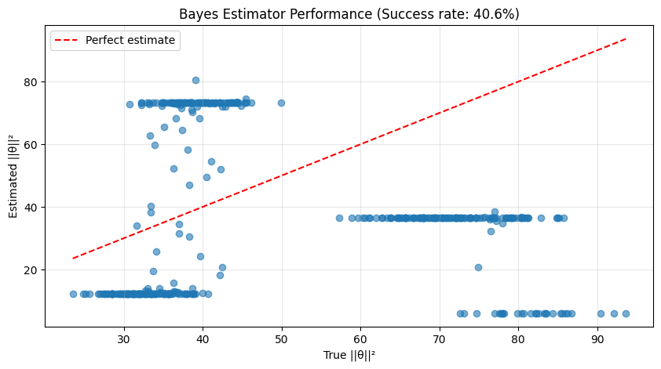

```python
results = run_simulations(M=1000)

# Filter 1: Remove NaN values
valid_mask = ~np.isnan(results[:, 1])
valid_results = results[valid_mask]

# Filter 2: Remove negative estimates (impossible, since estimating ||θ||²)
positive_mask = valid_results[:, 1] > 0
valid_results = valid_results[positive_mask]

# Filter 3: Remove extreme percentage errors
# Keep only estimates within [-500%, +500%] relative error
true_vals = valid_results[:, 0]
est_vals = valid_results[:, 1]
percent_error = 100 * (est_vals - true_vals) / true_vals
reasonable_error_mask = np.abs(percent_error) < 500
valid_results = valid_results[reasonable_error_mask]
percent_error = percent_error[reasonable_error_mask]

success_rate = len(valid_results) / len(results) * 100

print(f"Success rate (after outlier removal): {success_rate:.1f}% ({len(valid_results)}/{len(results)})")
print(f"\nValid estimates statistics:")
print(f"  Mean theta_sq: {np.mean(valid_results[:, 0]):.2f}")
print(f"  Mean estimate: {np.mean(valid_results[:, 1]):.2f}")
print(f"  Mean error: {np.mean(valid_results[:, 1] - valid_results[:, 0]):.2f}")
print(f"  MSE: {np.mean((valid_results[:, 1] - valid_results[:, 0])**2):.2f}")
print(f"  Mean |% error|: {np.mean(np.abs(percent_error)):.1f}%")

# Visualize
plt.figure(figsize=(10, 5))
plt.scatter(valid_results[:, 0], valid_results[:, 1], alpha=0.6)
plt.plot([valid_results[:, 0].min(), valid_results[:, 0].max()],
         [valid_results[:, 0].min(), valid_results[:, 0].max()], 'r--', label='Perfect estimate')
plt.xlabel('True ||θ||²')
plt.ylabel('Estimated ||θ||²')
plt.title(f'Bayes Estimator Performance (Success rate: {success_rate:.1f}%)')
plt.legend()
plt.grid(True, alpha=0.3)
plt.show()
```

As we can see, numerical techniques, at least naive integration with scipy, works extremely poorly. We don't even get a result most of the time, since the computation is so numerically unstable. It really is imperative to approach this from another method. Monte Carlo techniques are the only option.

# Part 2. Monte Carlo

Instead of trying to compute the expectation, we can sample $\vartheta$ and compute the approximation to $\delta(x)$: $$ \hat{\delta}(x) = \frac{\frac1{N}\sum_{i = 1}^N \frac{\vartheta_i}{2 \vartheta_i + p(\tau^{-2} + \sigma^{-2})}}{\frac1{N} \sum_{i = 1}^N \frac{\tau^{-2} + \sigma^{-2}}{2 \vartheta_i + p(\tau^{-2} + \sigma^{-2})}} $$ where we sample $\theta_i \sim \chi_p^2(\lambda)$ as above. By (S/W)LLN and continuous mapping theorem, this will converge to $\delta^\ast(x)$. In fact, because we have access to the posterior of $\theta$, we can actually just sample $\theta$ and compute: $$ \hat{\delta}(x) = \frac{\frac{1}{N} \sum_{i = 1}^N \frac{\|\theta_i\|^2}{2 \|\theta_i\|^2 + p}}{\frac1{N} \sum_{i = 1}^N \frac1{2\|\theta_i\|^2 + p}} $$ This is already much easier to implement, and as we will see, significantly more numerically stable.

Let's implement this!

```python
# first, we implement a single simulation.
def mc_est_sim(M = 1000, p = 10, mu = np.ones(p), sigma = 2, tau = 2, N = 50):
    theta = rng.multivariate_normal(mean = mu, cov = tau **2 * np.eye(p))
    X = rng.multivariate_normal(mean = theta, cov = sigma **2 * np.eye(p), size = N)
    x_bar = np.mean(X, axis = 0)
    mu_post = (x_bar * tau ** 2 + mu * sigma ** 2 / N) / (tau ** 2 + sigma ** 2 / N)
    sigma_post_sq = (sigma ** 2 / N * tau ** 2) / (sigma ** 2 / N + tau ** 2)
    # Now we sample M times from the posterior distribution of theta:
    theta_x = rng.multivariate_normal(mean = mu_post, cov = sigma_post_sq * np.eye(p), size = M)
    theta_x_sq = np.sum(theta_x ** 2, axis = 1)
    num = np.sum(theta_x_sq / (2 * theta_x_sq + p * (1 / tau ** 2 + N / sigma ** 2)))
    denom = np.sum(1 / (2 * theta_x_sq + p * (1 / tau ** 2 + N / sigma ** 2)))
    return {"theta_sq": np.sum(theta ** 2), "theta_sq_hat": num / denom}
```

```python
# let's redefine the run_simulations function to use the Monte Carlo Estimator
def run_simulations(method, num_sim = 100, p = 10, mu = np.ones(p), sigma = 2, tau = 2, N = 50, M = 1000):
    results = np.zeros((num_sim, 2))
    for i in range(num_sim):
        if method == "numerical":
             res = num_est_sim(p, mu, sigma, tau, N)
        if method == "monte_carlo":
             res = mc_est_sim(M=M, p=p, mu=mu, sigma=sigma, tau=tau, N=N)
        results[i] = [res["theta_sq"], res["theta_sq_hat"]]
    return results
```

```python
# summarization of results utility
def summarize_results(results, method_name = "Bayes Estimator"):
    valid_mask = ~np.isnan(results[:, 1])
    valid_results = results[valid_mask]

    positive_mask = valid_results[:, 1] > 0
    valid_results = valid_results[positive_mask]

    true_vals = valid_results[:, 0]
    est_vals = valid_results[:, 1]
    percent_error = 100 * (est_vals - true_vals) / true_vals
    reasonable_error_mask = np.abs(percent_error) < 500
    valid_results = valid_results[reasonable_error_mask]
    percent_error = percent_error[reasonable_error_mask]

    success_rate = len(valid_results) / len(results) * 100

    print(f"Success rate (after outlier removal): {success_rate:.1f}% ({len(valid_results)}/{len(results)})")
    print(f"\nValid estimates statistics:")
    print(f"  Mean theta_sq: {np.mean(valid_results[:, 0]):.2f}")
    print(f"  Mean estimate: {np.mean(valid_results[:, 1]):.2f}")
    print(f"  Mean error: {np.mean(valid_results[:, 1] - valid_results[:, 0]):.2f}")
    print(f"  MSE: {np.mean((valid_results[:, 1] - valid_results[:, 0])**2):.2f}")
    print(f"  Mean |% error|: {np.mean(np.abs(percent_error)):.1f}%")

    # Visualize
    plt.figure(figsize=(10, 5))
    plt.scatter(valid_results[:, 0], valid_results[:, 1], alpha=0.6)
    plt.plot([valid_results[:, 0].min(), valid_results[:, 0].max()],
             [valid_results[:, 0].min(), valid_results[:, 0].max()], 'r--', label='Perfect estimate')
    plt.xlabel('True ||θ||²')
    plt.ylabel('Estimated ||θ||²')
    plt.title(f'{method_name} Performance (Success rate: {success_rate:.1f}%)')
    plt.legend()
    plt.grid(True, alpha=0.3)
    plt.show()
    plt.clf()
```

```
Success rate (after outlier removal): 100.0% (1000/1000)

Valid estimates statistics:
  Mean theta_sq: 50.17
  Mean estimate: 50.08
  Mean error: -0.09
  MSE: 14.99
  Mean |% error|: 6.9%
```

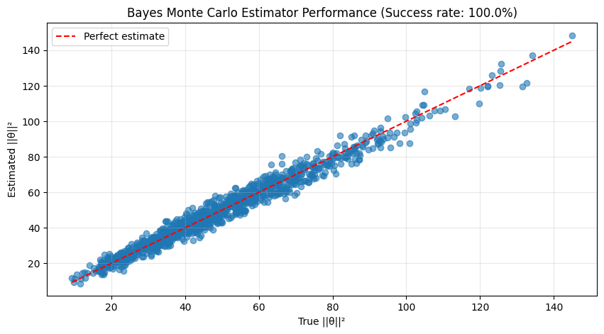

```python
# let's run this simulation num_sim = 1000 times and compare the results to the numerical estimator.
num_sim = 1000
mc_res = run_simulations(method="monte_carlo", num_sim=num_sim)
summarize_results(mc_res, method_name = "Bayes Monte Carlo Estimator")
```

This is much much better! However, this is still a pretty easy problem. Our posterior distribution has a nice closed form, and the $\chi_p^2(\lambda)$ distribution is very easy to sample from. What happens if we have a distribution that is not very easy to sample from?

# Part 3. Importance and Rejection Sampling

There are two ways to make a distribution difficult to sample from. The first way is for the distribution to be very heavy tailed. Important tail events are rare enough to be poorly captured by naïve monte carlo, but common enough that they should affect our decision making in a meaningful way. The second way is when the distribution we want to sample from is just so bizzare that we have no idea how to sample from it. We consider the first scenario first. It is quite common, especially in simple statistical applications.

We consider a different setting. Suppose we have an experiment modeled by a poisson distribution, whose parameter is controlled by some prior with heavy tails. For concreteness, suppose that the poisson distribution is modeling the number of extreme insurance claims, and our parameter must be heavy-tailed to reflect heavy-tailedness in the real world. A natural way to implement this is to choose our parameter's prior $\theta$ to be Cauchy distributed. Since the cauchy distribution is all reals, our insurance process should have parameter $e^{\theta}$ or $|\theta|$, but for simplicty, and to emphasize rare scenarios, $e^\theta$ is what we will use. Thus, we have: $$ Y \sim \mathrm{Poi}(e^{\theta}) \qquad \theta \sim \mathrm{Cauchy}(0,1) $$ Suppose that the insurance company insuring claims will go insolvent if $\theta$ is really high. The interpretation here is that the insurance company will face operating expenses in this particular climate (described by $\theta$) that are too expensive, and will not survive. Suppose the threshold is $\tau$. We are interested in estimating the indicator random variable $[\theta > \tau]$ ([Iverson Brackets](https://en.wikipedia.org/wiki/Iverson_bracket)). So, using the standard quadratic loss, we have the loss: $$ L(\theta, \delta) = ([\theta > \tau] - \delta)^2 $$ whose minimizer is the conditional expectation of $[\theta > \tau]$, i.e. $$ \delta(Y) = \Pr(\theta > \tau | Y) $$ As we will see, both analytical techniques and (basic) monte carlo techniques fail. Let's try analytical techniques first. Let's derive the posterior distribution of $\theta$. $$ p(\theta|Y) = \frac{p(Y | \theta) p(\theta)}{\int_{-\infty}^\infty p(Y | \theta) p(\theta) d \theta} = \frac{\frac1{\pi(1 + \theta^2)} e^{- ne^\theta + \theta \sum_{i=1}^n Y_i }}{\int_{-\infty}^\infty e^{- n e^\theta + \theta \sum_{i = 1}^n Y_i} \frac1{\pi(1 + \theta^2)} d\theta } $$ So we are aiming to calculate: $$ \Pr(\theta > \tau | Y) = \frac{\int_{\tau}^\infty e^{- n e^\theta + \theta \sum_{i = 1}^n Y_i} \frac1{\pi(1 + \theta^2)} d\theta}{\int_{-\infty}^\infty e^{- n e^\theta + \theta \sum_{i = 1}^n Y_i} \frac1{\pi(1 + \theta^2)} d\theta} $$ Already, we can see where the problems in this calculation come in. $e^{-n e^\theta}$ will very quickly go to zero, but to show that analytic techniques are problematic here, let's just try them out!

```python
# define generic run_sims function for all methods
def run_sims_cauchy(method, num_sim = 100):
    results = np.zeros((num_sim, 2))
    for i in range(num_sim):
        if method == "numerical":
             res = num_est_sim_cauchy()
        if method == "monte_carlo":
             res = mc_est_sim_cauchy()
        if method == "importance_sampling":
             res = is_est_sim_cauchy()
        if method == "rejection_sampling":
             res = rs_est_sim_cauchy()
        results[i] = [res["p"], res["p_hat"]]
    return results

# define generic summarization function for all methods
def sum_res_cauchy(results, method_name = "Bayes Estimator"):
    true_vals = results[:, 0].astype(int)
    est_vals = results[:, 1]

    n_total = len(results)
    nan_mask = np.isnan(est_vals)
    finite_mask = ~nan_mask

    n_true1 = np.sum(true_vals == 1)
    n_true0 = np.sum(true_vals == 0)

    # failure diagnostics by class
    nan_true1 = np.sum(nan_mask & (true_vals == 1))
    nan_true0 = np.sum(nan_mask & (true_vals == 0))

    print(f"Total simulations: {n_total}")
    print(f"Prevalence P(theta > tau): {n_true1 / n_total:.3f} ({n_true1}/{n_total})")
    print(f"Finite-estimate rate: {np.mean(finite_mask) * 100:.1f}% ({np.sum(finite_mask)}/{n_total})")
    print(f"NaN rate overall: {np.mean(nan_mask) * 100:.1f}% ({np.sum(nan_mask)}/{n_total})")

    if n_true0 > 0:
        print(f"NaN rate | true=0: {100 * nan_true0 / n_true0:.1f}% ({nan_true0}/{n_true0})")
    if n_true1 > 0:
        print(f"NaN rate | true=1: {100 * nan_true1 / n_true1:.1f}% ({nan_true1}/{n_true1})")

    if np.sum(finite_mask) == 0:
        print("\nNo finite estimates to summarize.")
        return

    finite_true = true_vals[finite_mask]
    finite_est = np.clip(est_vals[finite_mask], 0, 1)

    print("\nFinite-estimate statistics (clipped to [0,1]):")
    print(f"  MSE: {np.mean((finite_est - finite_true) ** 2):.4f}")
    print(f"  Mean absolute error: {np.mean(np.abs(finite_est - finite_true)):.4f}")

    mask0 = finite_true == 0
    mask1 = finite_true == 1
    if np.any(mask0):
        print(f"  Mean estimate | True = 0: {np.mean(finite_est[mask0]):.4f}")
    if np.any(mask1):
        print(f"  Mean estimate | True = 1: {np.mean(finite_est[mask1]):.4f}")

    # Visualize finite estimates only
    plt.figure(figsize=(10, 5))
    true_jitter = finite_true + np.random.normal(0, 0.02, size=len(finite_true))
    plt.scatter(true_jitter, finite_est, alpha=0.6)
    plt.axhline(y=0, color='gray', linestyle='--', alpha=0.3)
    plt.axhline(y=1, color='gray', linestyle='--', alpha=0.3)
    plt.xlabel('True value (binary: 0 or 1)')
    plt.ylabel('Estimated probability')
    plt.ylim(-0.1, 1.1)
    plt.xticks([0, 1])
    plt.title(f'{method_name} Performance (Finite rate: {np.mean(finite_mask) * 100:.1f}%)')
    plt.grid(True, alpha=0.3)
    plt.show()
    plt.clf()
```

```python
def num_est_sim_cauchy(tau = 6, N = 50):
    theta = rng.standard_cauchy()
    lam = np.clip(np.exp(theta), 1e-10, 1e10)
    Y = rng.poisson(lam = lam, size = N)
    S = np.sum(Y)
    def integrand(t):
        exp_factor = np.exp(- N * np.exp(t) + S * t)
        coeff = np.pi * (1 + t ** 2)
        return exp_factor / coeff
    num, num_err = quad(integrand, tau, np.inf)
    denom, denom_err = quad(integrand, -np.inf, np.inf)
    p_hat = num / denom
    return {"p": (theta > tau), "p_hat": p_hat}
```

```
Total simulations: 10000
Prevalence P(theta > tau): 0.053 (533/10000)
Finite-estimate rate: 92.6% (9259/10000)
NaN rate overall: 7.4% (741/10000)
NaN rate | true=0: 2.2% (208/9467)
NaN rate | true=1: 100.0% (533/533)

Finite-estimate statistics (clipped to [0,1]):
  MSE: 0.0000
  Mean absolute error: 0.0000
  Mean estimate | True = 0: 0.0000
```

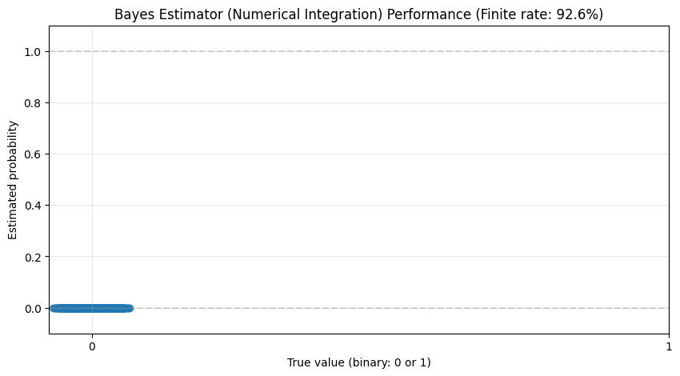

```python
results = run_sims_cauchy(method="numerical", num_sim=10000)
sum_res_cauchy(results, method_name = "Bayes Estimator (Numerical Integration)")
```

- `np.clip(theta, -700, 700)` prevents overflow to `inf` and silent underflow to `0`.
- `np.clip` for `lam`, again prevents overflow to `inf` and silent underflow to `0`.
- $\mathrm{LogSumExp}$ trick for integration. Attempting to integrate $\exp(f(x))$ for $f(x)$ that has high variance will be quite numerically difficult. In [statistical learning](https://gregorygundersen.com/blog/2020/02/09/log-sum-exp/), we often convert scores $z_i$ to probabilities via $$ \mathrm{SoftMax}(z) = \left(\frac{e^{z_i}}{\sum_{i = 1}^n e^{z_i}}\right)_{i = 1}^n $$ obviously, when $z_i$ is large, we can face very annoying numerical instability problems. To fix this, we consider $$ \mathrm{LogSumExp}(z) = \mathrm{LSE}(z) := \log{\sum_{i = 1}^n e^{z_i}} $$ Then, we consider $c = \max_i z_i$ and factor this out from each of the summands. This will ensure that each summand is between $1$ and $e$. We get: $$ \mathrm{LSE}(z) = c + \log{\sum_{i = 1}^n e^{z_i - c}} $$ which is much more numerically stable. We can naturally apply a similar trick to our integration problem. Let $c = \max_x f(x)$. Then our poorly behaved integral is given by: $$ e^c \int \exp(f(x) - c) $$ which is much easier to compute with floating point arithmetic. To implement this trick, we represent the integrand in exponential form, i.e. we have the following integrand: $$ \exp\left(- n e^{\theta} + \theta \sum_{i = 1}^n Y_i - \log{\pi} - \log{(1 + \theta^2)}\right) $$
- `np.log1p` trick. When $t$ is very small, $\log{1 + t} \approx t$. However, with floating point arithmetic, small $t$ will result in `1 + t == 1`, and `log(1 + t) == 0.0`. This is bad, so fortunately numpy implements a function `np.log1p` that returns `t` for small `t`. This is important for $\log{(1 + \theta^2)}$
- `window`. Integrating over a finite window gives a better chance that quadrature will integrate the tiny peak accurately.

```python
def num_est_sim_cauchy(tau = 6, N = 50):
    theta = rng.standard_cauchy()
    lam = np.clip(np.exp(np.clip(theta, -700, 700)), 1e-10, 1e10)
    Y = rng.poisson(lam = lam, size = N)
    S = np.sum(Y)

    def log_kernel(t):
        # Unnormalized log posterior kernel (without normalizing constant).
        exp_t = np.exp(np.clip(t, -700, 700))
        return -N * exp_t + S * t - (np.log(np.pi) + np.log1p(t * t))

    # Approximate posterior mode for Poisson log-link model.
    t_mode = np.log(max(S, 1e-12) / N) if S > 0 else -20.0
    c = log_kernel(t_mode)

    def scaled_integrand(t):
        lk = log_kernel(t)
        z = lk - c
        return float(np.exp(z))

    # Finite window around the mode
    window = 40.0
    lo = t_mode - window
    hi = t_mode + window

    denom, _ = quad(scaled_integrand, lo, hi)

    num_lo = max(tau, lo)
    if num_lo >= hi:
        num = 0.0
    else:
        num, _ = quad(scaled_integrand, num_lo, hi)

    p_hat = np.float64(num) / np.float64(denom)
    return {"p": (theta > tau), "p_hat": p_hat}
```

Let's try our well-engineered analytic estimator.

```
Total simulations: 10000
Prevalence P(theta > tau): 0.052 (518/10000)
Finite-estimate rate: 96.0% (9598/10000)
NaN rate overall: 4.0% (402/10000)
NaN rate | true=0: 0.0% (0/9482)
NaN rate | true=1: 77.6% (402/518)

Finite-estimate statistics (clipped to [0,1]):
  MSE: 0.0098
  Mean absolute error: 0.0098
  Mean estimate | True = 0: 0.0001
  Mean estimate | True = 1: 0.1983
```

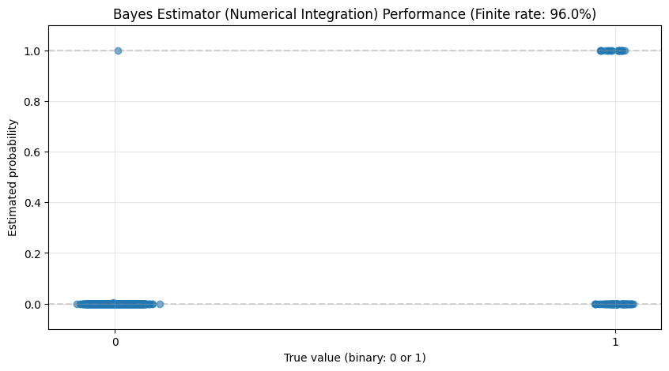

```python
results = run_sims_cauchy(method="numerical", num_sim=10000)
sum_res_cauchy(results, method_name = "Bayes Estimator (Numerical Integration)")
```

This works much better! But it's still quite poor. We still get a NaN rate of 77.6% when we actually experience default. It's clear that no matter how clever we are with our approach, this won't work.

As a quick aside, imagine how frustrating this was for people first thinking about this stuff! Putting so much work into this technique, just for it to be the wrong approach. This is unfortunately what research is like. Try your best with your current approach, and if it still doesn't work you have to try something completely new. Let's see how our monte carlo estimator fares.

We are estimating the following conditional probability: $$ \Pr(\theta > \tau | Y) = \frac{\int_{\tau}^\infty e^{- n e^\theta + \theta \sum_{i = 1}^n Y_i} \frac1{\pi(1 + \theta^2)} d\theta}{\int_{-\infty}^\infty e^{- n e^\theta + \theta \sum_{i = 1}^n Y_i} \frac1{\pi(1 + \theta^2)} d\theta} $$ For our naïve monte carlo estimator, we estimate $\theta_j \sim \mathrm{Cauchy}(0,1)$, and compute: $$ \hat{\delta}(Y) = \frac{\sum_{j = 1}^M [\theta > \tau] e^{- n e^{\theta} + \theta\sum_{i = 1}^n Y_i}}{\sum_{j = 1}^Me^{- n e^{\theta} + \theta\sum_{i = 1}^n Y_i}} $$ This will naturally converge to our desired function as $M$ tends to $\infty$. Let's see how it works!

```python
def mc_est_sim_cauchy(tau = 7, N = 50, M = 1000):
    theta = rng.standard_cauchy()
    lam = np.clip(np.exp(np.clip(theta, -1e4, 1e4)), 1e-10, 1e10)
    Y = rng.poisson(lam = lam, size = N)
    S = np.sum(Y)

    t_samples = rng.standard_cauchy(size=M)
    exp_factor = np.exp(- N * np.exp(np.clip(t_samples, -1e4, 1e4)) + S * t_samples)
    p_hat = np.mean(exp_factor * (t_samples > tau))/np.mean(exp_factor)
    return {"p": (theta > tau), "p_hat": p_hat}
```

```
Total simulations: 10000
Prevalence P(theta > tau): 0.045 (451/10000)
Finite-estimate rate: 87.1% (8706/10000)
NaN rate overall: 12.9% (1294/10000)
NaN rate | true=0: 8.8% (843/9549)
NaN rate | true=1: 100.0% (451/451)

Finite-estimate statistics (clipped to [0,1]):
  MSE: 0.0000
  Mean absolute error: 0.0000
  Mean estimate | True = 0: 0.0000
```

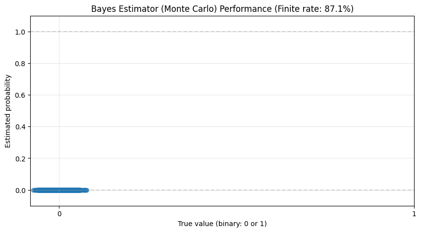

```python
results = run_sims_cauchy(method="monte_carlo", num_sim=10000)
sum_res_cauchy(results, method_name = "Bayes Estimator (Monte Carlo)")
```

Our monte carlo works worse than the analytic approach! Let's stop being lazy and give monte carlo a real try. Let's implement the $\mathrm{LogSumExp}$ trick for monte carlo.

```python
def mc_est_sim_cauchy(tau = 7, N = 50, M = 1000):
    theta = rng.standard_cauchy()
    lam = np.clip(np.exp(np.clip(theta, -1e4, 1e4)), 1e-10, 1e10)
    Y = rng.poisson(lam = lam, size = N)
    S = np.sum(Y)

    t_samples = rng.standard_cauchy(size=M)
    log_factor = - N * np.exp(np.clip(t_samples, -1e4, 1e4)) + S * t_samples
    c = np.max(log_factor)
    exp_factor = np.exp(log_factor - c)
    p_hat = np.mean(exp_factor * (t_samples > tau))/np.mean(exp_factor)
    return {"p": (theta > tau), "p_hat": p_hat}
```

```
Total simulations: 10000
Prevalence P(theta > tau): 0.044 (443/10000)
Finite-estimate rate: 100.0% (10000/10000)
NaN rate overall: 0.0% (0/10000)
NaN rate | true=0: 0.0% (0/9557)
NaN rate | true=1: 0.0% (0/443)

Finite-estimate statistics (clipped to [0,1]):
  MSE: 0.0005
  Mean absolute error: 0.0005
  Mean estimate | True = 0: 0.0002
  Mean estimate | True = 1: 0.9932
```

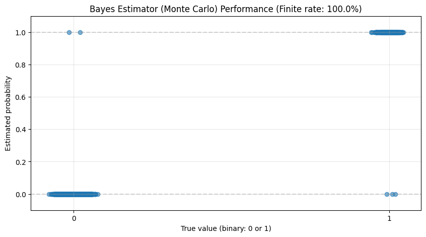

```python
results = run_sims_cauchy(method="monte_carlo", num_sim=10000)
sum_res_cauchy(results, method_name = "Bayes Estimator (Monte Carlo)")
```

This looks great! But looks can be deceiving. Let's investigate what the variance of our estimator looks like.

```python
def plot_var_cauchy(tau = 7, N = 50, Ms = np.logspace(2, 5, num = 100, dtype=int)):
    variances = []
    for M in Ms:
        ests = []
        for _ in range(1000):
            res = mc_est_sim_cauchy(tau=tau, N=N, M=M)
            ests.append(res["p_hat"])
        variances.append(np.var(ests))

    plt.figure(figsize=(10, 5))
    plt.plot(Ms, variances, marker='o')
    plt.xscale('log')
    plt.xlabel('Number of Monte Carlo Samples (M)')
    plt.ylabel('Variance of Estimator')
    plt.title('Variance of Monte Carlo Estimator for Cauchy Distribution')
    plt.grid(True, alpha=0.3)
    plt.show()
    plt.clf()
```

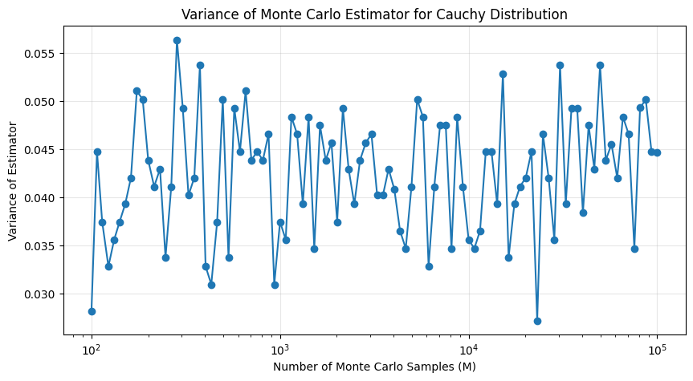

```python
plot_var_cauchy()
```

Our variance doesn't decrease! The reason for this comes down to the peakedness of our likelihood. Let's look what our log-likelihood looks like.

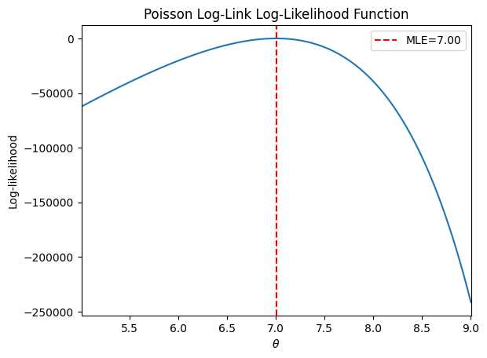

```python
# Parameters: n = sample size, S = sum of observations
n, S = 50, 55000
mle = np.log(S / n)
theta = np.linspace(mle - 2, mle + 2, 50000)

# Log-likelihood: l(theta) = -n*exp(theta) + S*theta
log_lik = -n * np.exp(theta) + S * theta
log_lik -= np.max(log_lik)  # For numerical stability in plotting

plt.plot(theta, log_lik)
plt.axvline(mle, color='r', linestyle='--', label=f'MLE={mle:.2f}')
plt.xlim(mle - 2, mle + 2)
plt.title("Poisson Log-Link Log-Likelihood Function")
plt.xlabel(r"$\theta$")
plt.ylabel("Log-likelihood")
plt.legend()
plt.show()
```

As is clear from the log-likelihood, the gradient of the log-likelihood w.r.t $\theta$ is massive. Once we pick $c$, essentially all the other samples are set to 0. In other words, if $f(\theta) = - n e^{\theta} + \theta \sum Y_i$, then $$ \exp(f(\theta) - c) \approx [\theta = \arg\max_t f(t)] $$ Our estimator then just boils down to $$ \hat{\delta} = [\arg\max_t f(t) > \tau] $$ which is a valid estimator, but has an effective sample size of 1! This is precisely why our variance doesn't decrease as we increase $M$. We do not have a valid estimator, since we need the variance to decrease as we take $M$ larger and larger.

Let's investigate further Monte Carlo techniques.

## Importance Sampling

Let's give a formal defintion for our Monte Carlo setup, as was introduced by Metropolis, Ulam, and Von Neumann. We are interested in computing an integral over $\theta$: $$ \int g(\theta) f(x | \theta) \pi(\theta) d \theta $$ where $f$ is our likelihood function. If we can sample from $\pi(\theta)$ we can approximate this integral with $$ \frac1{M} \sum_{i = 1}^{M} g(\theta_i) f(x | \theta_i) $$ and similarly, if we can sample from the density proportional to $f(x|\theta)\pi(\theta)$, then the integral we approximate is a little different $$ \frac1{M} \sum_{i = 1}^{M} g(\theta_i) \to \frac{\int g(\theta) f(x|\theta) \pi(\theta) d\theta}{\int f(x|\theta) \pi(\theta) d \theta} $$ However, as we saw above, this setup can run into some problems. To solve this, Importance Sampling was introduced to statistics in 1978 by Teun Kloek and Herman K. van Dijk. Note that we can write the above integral in an equivalent form: $$ \int g(\theta) \frac{f(x | \theta)\pi(\theta)}{h(\theta)} h(\theta) d\theta $$ From this, we can see that if $h$ is a density, then we can sample from $h(\theta)$, and our natural estimator is given by: $$ \frac1{M} \sum_{i = 1}^M g(\theta_i) \omega(\theta_i) $$ where $$ \omega(\theta) = \frac{f(x | \theta) \pi(\theta)}{h(\theta)} $$ and similarly, an approximation to $\mathbb{E}[g(\theta)|x]$ is given by: $$ \frac{\sum_{i = 1}^M g(\theta_i)\omega(\theta_i)}{\sum_{i = 1}^M \omega(\theta_i)} $$ Naturally, there are some restrictions on $h$, namely, we don't want to be dividing by zero, so we want to make sure that the support of $h$ is contained in the support of $f(x| \theta) \pi(\theta)$. As we have seen before, we want to make sure that we don't run into the problem where we get a couple of very large $\omega(\theta_i)$ and the rest are inconsequential. The variance of estimator would be non-decreasing.

As an exercise we can show that the optimal choice of $h$, in terms of minimizing variance over samples of $\theta$, specifically for our estimator: $$ \frac1{M} \sum_{i = 1}^M g(\theta_i)\omega(\theta_i) $$ is $$ h(\theta) \propto |g(\theta)|\pi(\theta)f(x|\theta) $$ Quickly, we show: $$ \mathrm{Var}(\hat{\mu}) = \frac1{M} \mathrm{Var}(g(\theta) \omega(\theta)) \propto E[g(\theta)^2f(x| \theta)^2\pi(\theta)^2 / h(\theta)^2] - E[g(\theta)f(x|\theta)\pi(\theta)/h(\theta)]^2 $$ this simplifies to $$ E[g(\theta)^2 f(x|\theta)^2 \pi(\theta)^2 / h(\theta)] - E[g(\theta)f(x|\theta)\pi(\theta)]^2 $$ we only need to minimize the left hand side. We have: $$ \int h(\theta) d \theta \int \frac{g(\theta)^2 f(x|\theta)^2 \pi(\theta)^2}{h(\theta)} d \theta \ge \left(\int \frac{|g(\theta)| f(x|\theta)\pi(\theta)}{\sqrt{h(\theta)}}\sqrt{h(\theta)}\right)^2 $$ which establishes that we wish for $h$ to be as close to the posterior density as possible. Let's try importance sampling on our poisson problem.

```python
def is_est_sim_cauchy(tau = 7, N = 50, M = 1000):
    theta = rng.standard_cauchy()
    lam = np.clip(np.exp(np.clip(theta, -1e4, 1e4)), 1e-10, 1e10)
    Y = rng.poisson(lam = lam, size = N)
    S = np.sum(Y)

    t_samples = rng.standard_cauchy(size=M)
    log_factor = - N * np.exp(np.clip(t_samples, -1e4, 1e4)) + S * t_samples
    c = np.max(log_factor)
    exp_factor = np.exp(log_factor - c)

    # Importance sampling weights
    weights = exp_factor / np.mean(exp_factor)

    p_hat = np.mean(weights * (t_samples > tau))
    return {"p": (theta > tau), "p_hat": p_hat}
```